# Bilimsel Hikaye Anlatıcılığına Giriş

## 1.4 Hatta grafiğini yapalım!

R bize aynı zamanda bu dağılımı görselleştirme imkanı da sunuyor. Mesela **kutu grafikleri** (`boxplot`) elimizdeki verinin dağılımını gösteren yegane görselleştirme metodudur. Burada `boxplot` fonksiyonu ile birlikte bir rakam vektörü kullanmamız gerektiğine dikkat edin lütfen. Yani sadece **sürekli (continious)** veri tipleriyle işlem yapabiliriz. Faktör gibi **kategori (disecrete)** veri tipleri tek başlarına kullanılamaz.

Burada kullandığımız `outline` opsiyonu, outlier değerlerin gösterilmemesi gerektiğini belirtmektedir.

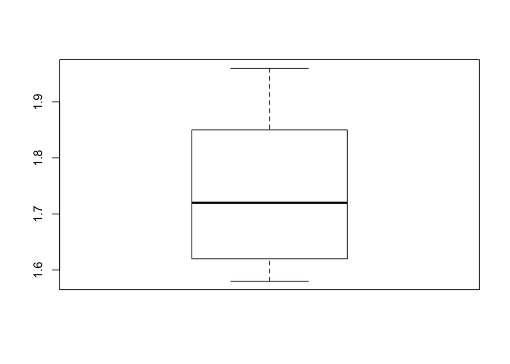

```r
boxplot(sinif$boy, outline = FALSE)
```

Kutu grafikleri, sürekli veri tiplerinin dağılımını görselleştirir. Ortadaki kalın çizgi bize ortanca değeri gösterir.

- En aşağıdaki çizgi ise minimum değeri
- kesikli çizgi birinci çeyreklik kısmı
- kutu içerisinde ikinci ve üçüncü çeyreklik kısımlar ortanca değer ile ayrılır
- en üstteki değerle kutunun arasındaki kesikli çizgi ise dördüncü çeyrekliği gösterir

İsterseniz siniftaki insanların ağırlıklarını da tanımlayıcı istatistik yöntemleriyle inceleyelim:

```r
summary(sinif$kilo)
```

```
##    Min. 1st Qu.  Median    Mean 3rd Qu.    Max.
##   60.00   70.25   76.00   78.40   88.75  100.00
```

En hafif kişi 60 kilo, en ağır kişi ise 100 kiloymuş.

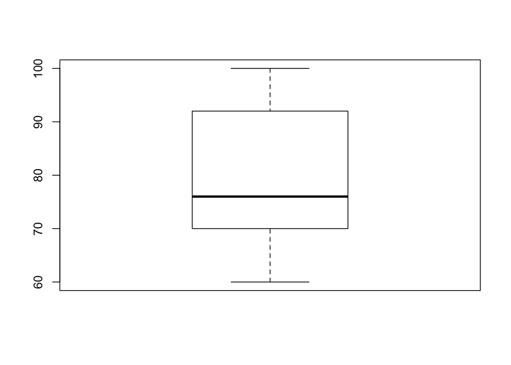

```r
boxplot(sinif$kilo)
```

Peki, siniftaki insanların boy dağılımı cinsiyete göre nasıl değişim gösteriyor? İşte faktör veri sınıfını kullanacağımız yere geldik!

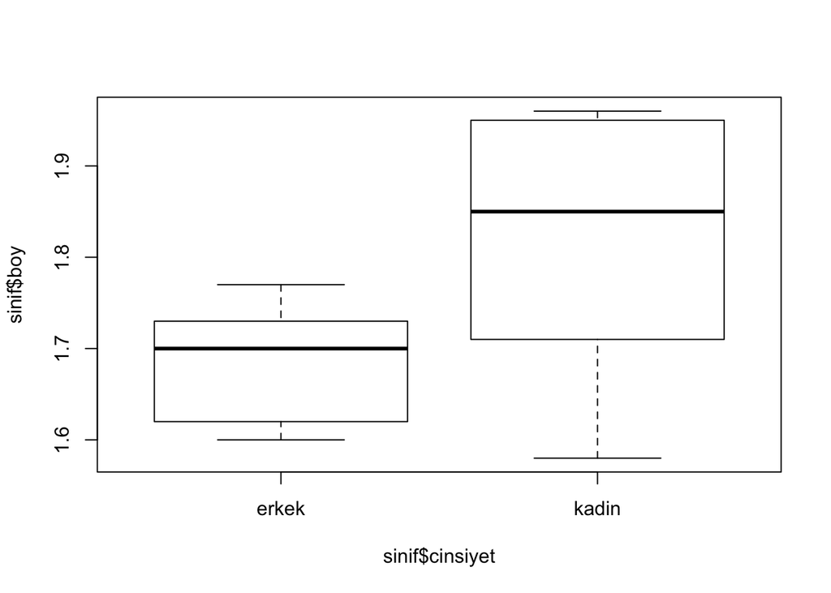

```r
boxplot(sinif$boy~sinif$cinsiyet)
```

Burada `~` işareti (sağ alt tuşu + ü), **soldaki değeri, sağdaki değere göre ifade et** şeklinde özetlenebilir. Aslında bir değişkeni, başka bir değişken kullanarak modelliyoruz. Bu konuya ilerleyen derslerde geleceğiz.

Dikkat ederseniz bu sınıftaki kadınlar, erkeklerden çok uzun. Siz de bilgisayarlarınızda aynısını, kişilerin kiloları için yapın. Ne sonuç bulacaksınız?

## 1.5 GGplot2!

Buraya kadar normal R grafiklerini gördük. Ancak R üzerinde başka görselleştirme kütüphaneleri de mevcuttur. Bunlardan bir tanesi de `ggplot2`.

Önce kütüphaneyi yükleyelim:

```r
library(ggplot2)
```

Kutu grafiğini yapalım:

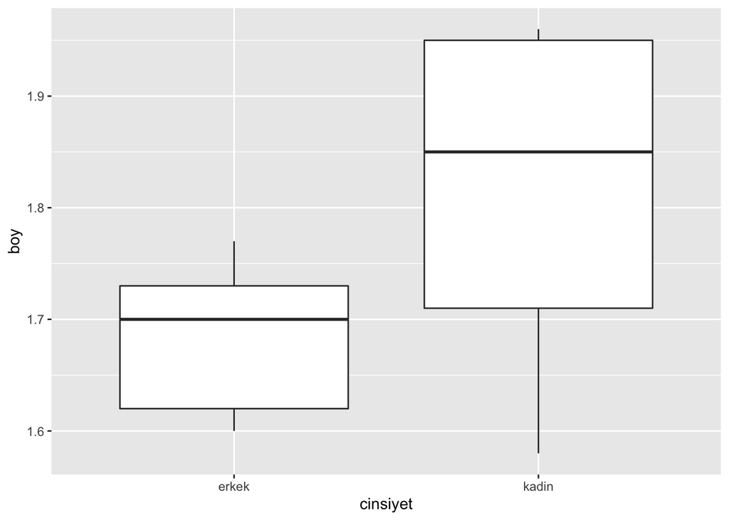

```r
ggplot(data = sinif, aes(x = cinsiyet, y = boy)) + geom_boxplot()
```